```python
from astropy.wcs import WCS
from reproject  import reproject_to_healpix, reproject_from_healpix
from astropy import units as u
from astropy.visualization import imshow_norm
import astropy.io.fits as fits
import healpy as hp
import pylab as pl
```

```python
from IPython.display import HTML

HTML('''<script>
code_show=true;
function code_toggle() {
 if (code_show){
 $('div.input').hide();
 } else {
 $('div.input').show();
 }
 code_show = !code_show
}
$( document ).ready(code_toggle);
</script>
<form action="javascript:code_toggle()"><input type="submit" value="Click here to toggle on/off the raw code."></form>''')
```

# Input Map in the Bicep pixelization

The `.csv` is a table with each row the coordinates RA and Dec and the value of the pixel in the BICEP pixelization. In this case we 're trying to reproject a map of the weights for B3 2016.

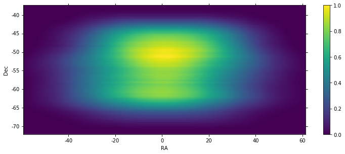

```python
ra,dec,hits= pl.loadtxt('B3_2016_hits_map.csv', comments='#', delimiter=',').T


deltadec=  ( (dec[1]-dec[0])  )
deltara =( (ra[140]-ra[0]) )
hdu = fits.BinTableHDU.from_columns(
 [fits.Column(name='RA', format='1D',unit='degrees', array=ra),
    fits.Column(name='DEC', format='1D', unit='degrees',array=dec),
  fits.Column(name='WEIGHT', format='1E', array=hits) ])

wcs = WCS(header = hdu.header, colsel=[0,1] )

fig = pl.figure(figsize=(10,4))
fig.add_subplot(111, projection=wcs)
mapreshaped=hdu.data['WEIGHT'].reshape(258,140)
extent=[ra[0] -deltara ,ra[-1]+ deltara, dec[0] - deltadec ,dec[-1] -deltadec]
pl.imshow(mapreshaped.T  ,   aspect='auto',cmap=pl.cm.viridis,extent=extent, vmin=.0 , vmax=1)
pl.xlabel('RA')
pl.ylabel('Dec')
pl.colorbar()
pl.tight_layout()
```

# Repixelization with Astropy-reproject

I 've found a python module [reproject](https://reproject.readthedocs.io/en/stable/index.html) that can perform the Healpix pixelization starting from a map in *Celestial* coordinates. There are several existing algorithms that can be used to reproject such data:

- **Interpolation** (e.g. nearest-neighbor, bilinear, biquadratic interpolation and so on). This is the fastest algorithm and is suited to common use cases, but it is important to note that *it is not flux conserving*, and will not return optimal results if the input and output pixel sizes are very different.
- **Drizzling** which consists of determining the exact overlap fraction of pixels, and optionally allows pixels to be rescaled before reprojection. A description of the algorithm can be found in [Fruchter and Hook (2002)](https://arxiv.org/abs/astro-ph/9808087). This is slower but more accurate than interpolation for small fields of view.
- **Spherical Polygon**, computing the exact overlap of pixels on the sky by treating them as four-sided spherical polygons on the sky and computing spherical polygon intersection. This is essentially an exact form of drizzling, and should be appropriate for any field of view. However, this comes at a significant performance cost. This is the algorithm used by the [Montage package](http://montage.ipac.caltech.edu/index.html).

Currently, `reproject` implements interpolation and spherical polygon intersection. For our purposes, I think it's worth to rely with interpolation since CMB maps are already in surface brightness and we are expecting to project input and output on nearly similar pixelsizes.

Once we define the coordinate frame we can use `reproject.reproject_to_healpix` to perform the interpolation and project into healpix grid ( another strong utility is that one can change the output coordinates : from Celestial to Galactic ones) .

We repixelize in Healpix with `nside=512`.

### Projection to Celestial

```python
nside=512; nested=False;  healpix_system='C'; image_system='C';
```

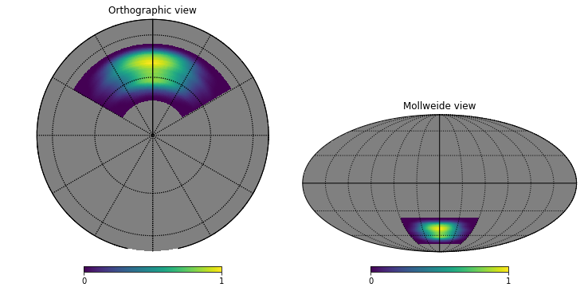

```python
def get_reference_header( minra,  mindec, deltara, deltadec ):
    reference_header = fits.Header()
    reference_header.update({
        'CDELT1':    deltara ,
        'CDELT2':    deltadec ,
        'CRPIX1':   0 ,
        'CRPIX2': 0,
        'CRVAL1':   minra,
        'CRVAL2':   mindec ,
        'CTYPE1': 'RA',
        'CTYPE2': 'DEC',
        'CUNIT1': 'deg',
        'CUNIT2': 'deg',
        'NAXIS': 2,
        'NAXIS1':1    ,
        'NAXIS2': 1  })

    return reference_header


header1 =  get_reference_header( minra= ra.min() ,
                                         mindec=dec.min(),
                                         deltara=deltara,
                                         deltadec=deltadec   )

header2 =  get_reference_header( minra= 360 + ra.min() ,
                                         mindec=dec.min(),
                                         deltara=deltara,
                                         deltadec=deltadec   )

wcs_out1= WCS( header1)
wcs_out2= WCS( header2)



healpix_data1, footprint1 = reproject_to_healpix(
        (mapreshaped.T, wcs_out1 ), healpix_system,
        nside=nside, order='nearest-neighbor', nested=nested)
healpix_data2, footprint2 = reproject_to_healpix(
        (mapreshaped.T, wcs_out2), healpix_system,
        nside=nside, order='nearest-neighbor', nested=nested)
mask1= pl.where(footprint1==1)
mask2=pl.where(footprint2==1)
totalmap=pl.zeros_like(footprint1)
totalmap[mask1]=  healpix_data1[mask1]
totalmap[mask2]= healpix_data2[mask2]
totalmap[ pl.logical_not(footprint1 +footprint2 ) ] =pl.nan
pl.figure(figsize=(10,5))
hp.orthview(totalmap , rot=[0,-90],   sub=121,   max=1, half_sky=True  )
hp.graticule(verbose=False)

hp.mollview(totalmap,   sub=122,   max=1)
hp.graticule(verbose=False)
pl.tight_layout()
```

### Projection to Galactic

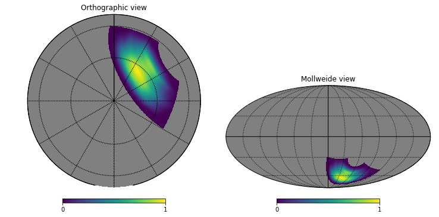

```python
 healpix_system='G';

header1 =  get_reference_header( minra= ra.min() ,
                                         mindec=dec.min(),
                                         deltara=deltara,
                                         deltadec=deltadec   )

header2 =  get_reference_header( minra= 360 + ra.min() ,
                                         mindec=dec.min(),
                                         deltara=deltara,
                                         deltadec=deltadec   )

wcs_out1= WCS( header1)
wcs_out2= WCS( header2)



healpix_data1, footprint1 = reproject_to_healpix(
        (mapreshaped.T, wcs_out1 ), healpix_system,
        nside=nside, order='nearest-neighbor', nested=nested)
healpix_data2, footprint2 = reproject_to_healpix(
        (mapreshaped.T, wcs_out2), healpix_system,
        nside=nside, order='nearest-neighbor', nested=nested)
mask1= pl.where(footprint1==1)
mask2=pl.where(footprint2==1)
totalmap=pl.zeros_like(footprint1)
totalmap[mask1]=  healpix_data1[mask1]
totalmap[mask2]= healpix_data2[mask2]
totalmap[ pl.logical_not(footprint1 +footprint2 ) ] =pl.nan
pl.figure(figsize=(10,5))
hp.orthview(totalmap , rot=[0,-90],   sub=121,   max=1, half_sky=True  )
hp.graticule(verbose=False)

hp.mollview(totalmap,   sub=122,   max=1)
hp.graticule(verbose=False)
pl.tight_layout()
```